# Survival analysis

# Introduction

## Fundamental concepts

$T$ … non-negative continuous random variable representing the time until the event occurs

$f(t)$ … probability density function

$F(t) = P(T < t)$ … cumulative distribution function

$S(t) = P(T \geq t) = 1 - F(t)$ … survival function

$h(t) =\frac{f(t)}{S(t)}$… hazard rate

$H(t)$ … cumulative hazard

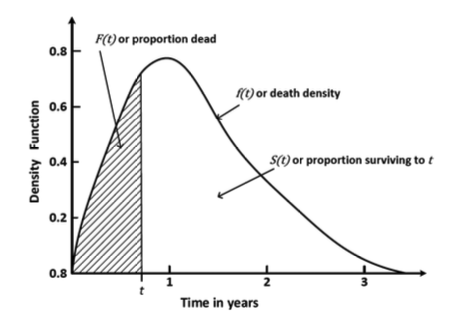

*Image source: https://arxiv.org/abs/1708.04649*

## Censored data

What distinguishes survival analysis from other areas in statistics is the data that are usually censored.

Censored data is **any data for which we do not know the exact event time**.

We distinguish between Type I and Type II censoring:

- In Type I censoring we observe all individuals for a specific time period or until failure.
- Type II censoring design can often be found in engineering, where a total of *n* objects are observed and the study ends when *r* of them fail.

Observations can be *point-censored* or *interval-censored*. Let’s take a look at point censoring:

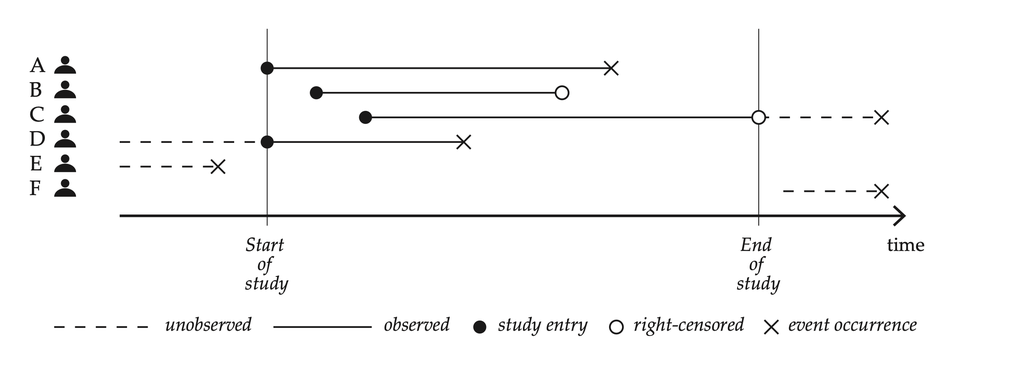

Interval censoring is shown in the bottom figure:

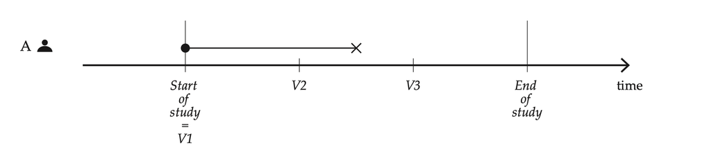

Now let’s get to know our data.

## The Rossi experiment

The dataset we’ll be working with today is one that was published in Peter H. Rossi, Richard A. Berk and Kenneth J. Lenihan’s 1980 book, *Money, Work, and Crime: Some Experimental Results* (https://gwern.net/doc/sociology/1980-rossi-moneyworkandcrime.pdf). The dataset is made available in the R *carData* package, and is described as follows:

> This data set is originally from Rossi et al. (1980), and is used as an example in Allison (1995). The data pertain to 432 convicts who were released from Maryland state prisons in the 1970s and who were followed up for one year after release. Half the released convicts were assigned at random to an experimental treatment in which they were given financial aid; half did not receive aid.

The [documentation page](https://vincentarelbundock.github.io/Rdatasets/doc/carData/Rossi.html) describes the columns that are present in the dataset.

```r
library(carData)
dat <- Rossi
summary(dat)
```

```
      week           arrest        fin           age          race      wexp              mar       paro          prio             educ        emp1       emp2       emp3       emp4       emp5       emp6       emp7       emp8       emp9
 Min.   : 1.00   Min.   :0.0000   no :216   Min.   :17.0   black:379   no :185   married    : 53   no :165   Min.   : 0.000   Min.   :2.000   no :372   no  :317   no  :293   no  :274   no  :258   no  :250   no  :249   no  :250   no  :237
 1st Qu.:50.00   1st Qu.:0.0000   yes:216   1st Qu.:20.0   other: 53   yes:247   not married:379   yes:267   1st Qu.: 1.000   1st Qu.:3.000   yes: 60   yes :114   yes :137   yes :155   yes :170   yes :177   yes :177   yes :175   yes :183
 Median :52.00   Median :0.0000             Median :23.0                                                     Median : 2.000   Median :3.000             NA's:  1   NA's:  2   NA's:  3   NA's:  4   NA's:  5   NA's:  6   NA's:  7   NA's: 12
 Mean   :45.85   Mean   :0.2639             Mean   :24.6                                                     Mean   : 2.984   Mean   :3.477
 3rd Qu.:52.00   3rd Qu.:1.0000             3rd Qu.:27.0                                                     3rd Qu.: 4.000   3rd Qu.:4.000
 Max.   :52.00   Max.   :1.0000             Max.   :44.0                                                     Max.   :18.000   Max.   :6.000
  emp10      emp11      emp12      emp13      emp14      emp15      emp16      emp17      emp18      emp19      emp20      emp21      emp22      emp23      emp24      emp25      emp26      emp27      emp28      emp29      emp30
 no  :222   no  :224   no  :225   no  :222   no  :231   no  :226   no  :225   no  :216   no  :209   no  :204   no  :206   no  :200   no  :195   no  :197   no  :204   no  :192   no  :187   no  :183   no  :179   no  :181   no  :187
 yes :196   yes :193   yes :190   yes :191   yes :181   yes :183   yes :182   yes :189   yes :193   yes :195   yes :191   yes :192   yes :195   yes :192   yes :184   yes :192   yes :194   yes :195   yes :197   yes :193   yes :187
 NA's: 14   NA's: 15   NA's: 17   NA's: 19   NA's: 20   NA's: 23   NA's: 25   NA's: 27   NA's: 30   NA's: 33   NA's: 35   NA's: 40   NA's: 42   NA's: 43   NA's: 44   NA's: 48   NA's: 51   NA's: 54   NA's: 56   NA's: 58   NA's: 58



  emp31      emp32      emp33      emp34      emp35      emp36      emp37      emp38      emp39      emp40      emp41      emp42      emp43      emp44      emp45      emp46      emp47      emp48      emp49      emp50      emp51
 no  :183   no  :183   no  :181   no  :185   no  :181   no  :176   no  :180   no  :175   no  :173   no  :173   no  :167   no  :170   no  :166   no  :164   no  :162   no  :160   no  :155   no  :154   no  :158   no  :158   no  :156
 yes :189   yes :188   yes :188   yes :182   yes :184   yes :185   yes :178   yes :179   yes :180   yes :178   yes :180   yes :177   yes :179   yes :177   yes :177   yes :177   yes :178   yes :178   yes :172   yes :167   yes :166
 NA's: 60   NA's: 61   NA's: 63   NA's: 65   NA's: 67   NA's: 71   NA's: 74   NA's: 78   NA's: 79   NA's: 81   NA's: 85   NA's: 85   NA's: 87   NA's: 91   NA's: 93   NA's: 95   NA's: 99   NA's:100   NA's:102   NA's:107   NA's:110



  emp52
 no  :156
 yes :166
 NA's:110
```

Let’s get to know our data better.

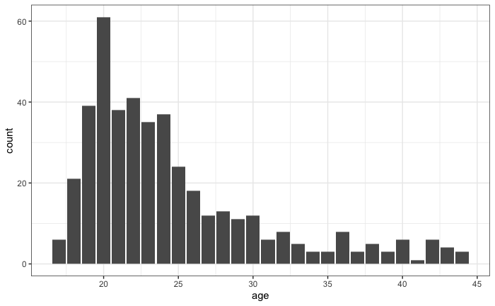

```r
ggplot(dat, aes(x=age)) + geom_bar() + theme_bw()
```

```r
binary_cols <- c("fin", "wexp", "mar", "paro")
summary(dat[, binary_cols])
```

```
  fin       wexp              mar       paro
 no :216   no :185   married    : 53   no :165
 yes:216   yes:247   not married:379   yes:267
```

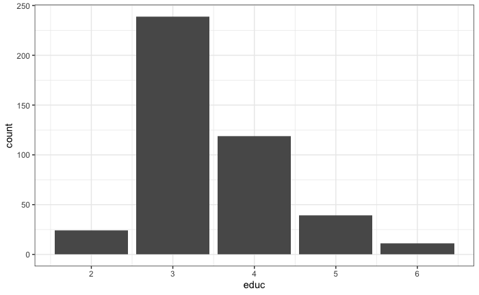

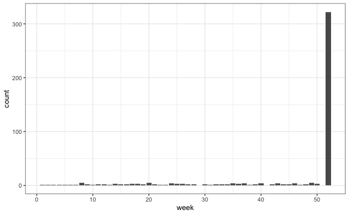

```r
summary(dat[, "arrest"])
```

```
   Min. 1st Qu.  Median    Mean 3rd Qu.    Max.
 0.0000  0.0000  0.0000  0.2639  1.0000  1.0000
```

**Q: What type of censored data are we dealing with?**

In this workshop, we focus on the Type I censoring design, our data is right-censored and we assume non-informative censoring, which means that the distribution of survival times provides no information about the distribution of censorship times and vice versa.

## How to handle censored data?

- **Complete data analysis**: ignore the censored observations
- **Imputation**
- **Dichotomized data analysis**
- **Likelihood-based approach**